# Board Quality Distribution Improvement via Log Segregation

JH

# Background

One motivation for log segregation in-mill is to alter the resulting board quality (stiffness, straightness, …) distributions, generally in order to “improve” them.

As a way of gauging how much effort should be put in to log segregation it is helpful to consider what level of improvement is derived from a variety of log culls.

For this purpose datasets are required that contain quality measurements for all boards from known logs. Datasets available:

- Hyne. 123 logs. 1201 boards. Tumbarumba
- PQPV. 292 logs 2280 boards. CNI. All logs from a single (clonal) genotype.
- LS15. 100 logs. 1949 board. CNI
- STR23. 72 logs. 1312 boards. CNI
- GreenLumber. 29 logs. 258 boards. CNI
- STA723 NZ Pilot Study. 24 logs. 109 boards! CNI. Boards dried unrestrained?
- STA15. 20 logs. 459 boards. CNI. Warp not measured with Joe90.

# Context

Why segregate? Optimise feedstock for a particular process (or set of processes).

When segregate? (a) When benefits outweigh costs, (b) when technically feasible (e.g when prediction ‘good enough’)

# Questions

How do warp distributions change as low stiffness logs culled?

Do the NZ and Aus resources differ?

# Methodology

1. get uncorrected data and plot for individual datasets. DONE
2. compare dataset uncorrected distributions.
3. correct for differences in:
- measurement units
- board length and dimensions
- moisture content
- sampling (each dataset log represents variable fraction of popn logs)
- number and position of recovered boards

```r
# libraries, functions, data structs
library(RODBC)
library(lattice)
library(ggplot2)
library(gridExtra)
bad.frac.rel = function(in.log, P, bad.pctile) {
  # what fraction of boards in this log are worse than the population bad.pctile
  # missing values are assumed to be distributed the same as non-missing
  ii.notna = in.log & !is.na(P)
  ii.bad = ii.notna & P>quantile(P,1-bad.pctile,na.rm=TRUE)
  return(sum(ii.bad)/sum(ii.notna))
}
bad.frac.abs = function(in.log, P, bad.limit) {
  # what fraction of boards in this log are worse than the population bad.pctile
  # missing values are assumed to be distributed the same as non-missing
  ii.notna = in.log & !is.na(P)
  ii.bad = ii.notna & P>bad.limit
  return(sum(ii.bad)/sum(ii.notna))
}
summarise.boards <- function(L,B) {
  for (i in 1:nrow(L)) {
    ii=!is.na(B$log) & as.character(B$log)==as.character(L[i,"log"])
    L[i,"nboards"]=sum(ii)
    L[i,"moe_avg"]=mean(B$moe[ii],na.rm=TRUE)
    L[i,"den_avg"]=mean(B$den[ii],na.rm=TRUE)
    L[i,"bow_avg"]=mean(B$bow[!is.na(B$bow) & ii])
    L[i,"bow_50"]=median(B$bow[!is.na(B$bow) & ii])
    L[i,"bow_75"]=quantile(B$bow[!is.na(B$bow) & ii], 0.75)
    L[i,"crook_avg"]=mean(B$crook[!is.na(B$crook) & ii])
    L[i,"crook_50"]=median(B$crook[!is.na(B$crook) & ii])
    L[i,"crook_75"]=quantile(B$crook[!is.na(B$crook) & ii], 0.75)
    L[i,"twist_avg"]=mean(abs(B$twist[!is.na(B$twist) & ii]))
    L[i,"twist_50"]=median(abs(B$twist[!is.na(B$twist) & ii]))
    L[i,"twist_75"]=quantile(abs(B$twist[!is.na(B$twist) & ii]), 0.75)
    #
    L[i,"bad.20.bow"]=bad.frac.rel(ii,  abs(B$bow), 0.2)
    L[i,"bad.20.crook"]=bad.frac.rel(ii, abs(B$crook), 0.2)
    L[i,"bad.20.twist"]=bad.frac.rel(ii, abs(B$twist), 0.2)
    #
    # NOTE: remember we using normalized warp. these limits are appropriate
    # for the Hyne dataset. they may NOT be for other datasets!!!
    L[i,"bad.MGP.bow"]=bad.frac.abs(ii,  abs(B$bow), 8*60/4.9^2)
    L[i,"bad.MGP.crook"]=bad.frac.abs(ii, abs(B$crook), 8*29/4.9^2)
    L[i,"bad.MGP.twist"]=bad.frac.abs(ii, abs(B$twist), asin(10/100)*180/4.9)
    L[i,"bad.MGP.moe"]=bad.frac.abs(ii, 1./abs(B$moe), 1./6.)
    #L[i,"bad.MGP.any"]=
  }
  return(L)
}
plot_prop = function(prop, ordering='moe_avg',decreasing=TRUE) {
  # todo:
  # - add trace of nboards to each plot
  # - use same ylims for all panels
  logs.in.desc.order = L$log[order(L[,ordering], decreasing=decreasing)]
  nlogs = nrow(L)
  X = data.frame()
  k = 1
  for (idrop in 1:nrow(L)) {
    X[k,"ndropped"] = idrop-1
    X[k,"cullfrac"] = 100*(idrop-1)/nrow(L)
    x = B[B$log%in%logs.in.desc.order[1:(nlogs-idrop+1)],prop]
    x = x[!is.na(x)]
    X[k,"min"] = min(x)
    X[k,"mean"] = mean(x)
    X[k,"max"] = max(x)
    X[k,"p90"] = quantile(x, 0.9)
    X[k,"p10"] = quantile(x, 0.1)
    X[k,"p50"] = quantile(x, 0.5)
    k = k + 1
  }
  return( ggplot(X, aes(x=cullfrac)) +
            geom_line(aes(y=mean), size=2) +
            geom_line(aes(y=p10)) +
            geom_line(aes(y=p90)) +
            xlab('% logs culled') +
            ylab(prop) +
            coord_cartesian(xlim=c(0,80))
          )
}
plot_dataset <- function(L,B,pdf=NULL) {
  # todo:
  # - same ylims for all panels of same prop
  # - swap orderings to columns rather than rows
  # - label only leftmost, bottom most axes
  # - reduce whitespace between panels
  # - label orderings
  # - make L,B local vars in plot_prop()!!!!!
  plots = list()
  for (p in c('moe','den','bow','crook','twist')) {
    for (o in c('moe_avg','den_avg','bow_75','crook_75','twist_75')) {
      plots = c(plots, list(plot_prop(p, ordering=o, decreasing=p%in%c('moe','den'))))
    }
  }
  if (!is.null(pdf)) pdf(pdf, width=10, height=20)
  multiplot(plotlist=plots, cols=5)
  if (!is.null(pdf)) dev.off()
}
DATASETS = list()

multiplot <- function(..., plotlist=NULL, file, cols=1, layout=NULL) {
  library(grid)

  # Make a list from the ... arguments and plotlist
  plots <- c(list(...), plotlist)

  numPlots = length(plots)

  # If layout is NULL, then use 'cols' to determine layout
  if (is.null(layout)) {
    # Make the panel
    # ncol: Number of columns of plots
    # nrow: Number of rows needed, calculated from # of cols
    layout <- matrix(seq(1, cols * ceiling(numPlots/cols)),
                    ncol = cols, nrow = ceiling(numPlots/cols))
  }

 if (numPlots==1) {
    print(plots[[1]])

  } else {
    # Set up the page
    grid.newpage()
    pushViewport(viewport(layout = grid.layout(nrow(layout), ncol(layout))))

    # Make each plot, in the correct location
    for (i in 1:numPlots) {
      # Get the i,j matrix positions of the regions that contain this subplot
      matchidx <- as.data.frame(which(layout == i, arr.ind = TRUE))

      print(plots[[i]], vp = viewport(layout.pos.row = matchidx$row,
                                      layout.pos.col = matchidx$col))
    }
  }
}
```

# Individual Datasets

## Hyne

1. log average board MOE
2. log average board density
3. 75%-ile bow
4. 75%-ile crook
5. 75%-ile twist

```r
ch = odbcConnect('Hyne',uid='sa',pwd="password12")
B = sqlQuery(ch, "
             select
                SWILogNumber log,
                8*abs(m.bow)/power(C_Length/1000,2) bow,
                8*abs(m.crook)/power(C_Length/1000,2) crook,
                asin(m.twist/(O_Width/10))*180/(C_Length/1000) twist,
                X_Dens den,
                X_AvgE/1000 moe
             from (
                select flitchId, max(pith) pith, max(wane) wane, avg(swv) swv, avg(bow) bow, avg(crook) crook, avg(twist) twist
                from manualMeas group by flitchId
             ) m
             left join CHHBoards c on c.flitchId=m.flitchId
             left join (
                select flitchId, max(SWILogNumber) SWILogNumber
                from boardEndImages i, barcode_image bi, boardEndBarcodes b
                where flitchId is not null and i.id=bi.imageId and bi.barcodeId=b.id group by flitchId
             ) f on f.flitchId=m.flitchId")
L = sqlQuery(ch, "select SWILogNumber log, volume vol, velocity swv from logs where SWILogNumber is not null and DateAndTime<'2014-08-31 00:00:00'")
L = summarise.boards(L,B)
#plot_dataset(L,B)
DATASETS = c(DATASETS, list(Hyne=list(L=L, B=B)))
```

### Stan’s Plot

Marco asked (on Stan’s behalf) for a barchart plotting “%age bad boards from this log” for each log (in order). Later, Keith asked to see the corresponding log SWV overplotted:

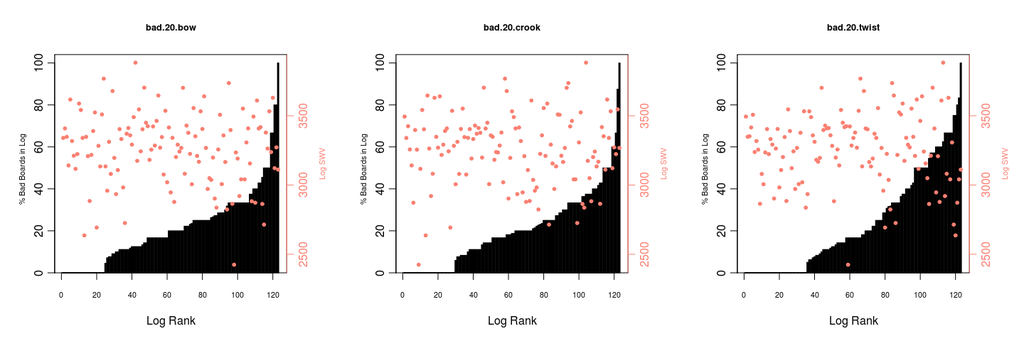

```r
# grid graphics don'ty seem to easily do multiple y-scales.
# ggvis can't be installed because can't build shiny.
# try plotrix:
library(plotrix)
mybarchart.plotrix = function(p) {
  LL = L[order(L[,p]),]
  log.frac = c(1:nrow(LL))#/nrow(LL))
  twoord.plot(log.frac,LL[,p]*100,
              log.frac,LL$swv,
              xlab="Log Rank",
              type=c("bar","p"),
              ylab="% Bad Boards in Log ",
              rcol='salmon',#'grey30',
              rpch=19,
              rylab="Log SWV",
              main=p)
  }
par(mfcol=c(1,3))
mybarchart.plotrix('bad.20.bow')
mybarchart.plotrix('bad.20.crook')
mybarchart.plotrix('bad.20.twist')
```

Instead of using a relative measure of badness (i.e. the 20th%ile) plot again using absolute (MGP?) limits (bow<60mm, crook<29mm, twist<10mm):

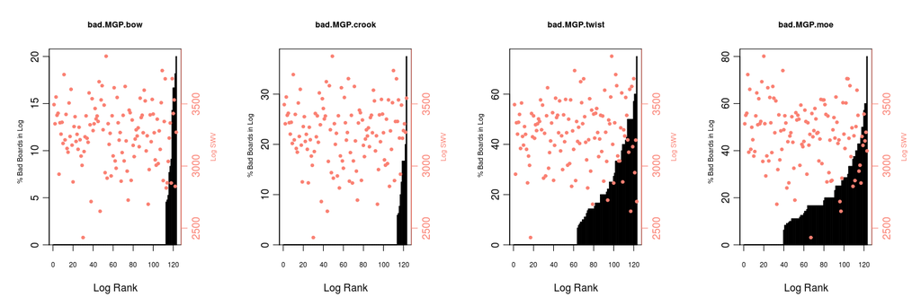

```r
par(mfcol=c(1,4))
mybarchart.plotrix('bad.MGP.bow')
mybarchart.plotrix('bad.MGP.crook')
mybarchart.plotrix('bad.MGP.twist')
mybarchart.plotrix('bad.MGP.moe')
```

Two perspectives:

- is this log ‘good’ or ‘bad’ - important if you’re trying to minimise processing costs. ‘bad’ logs are going to waste time and yield little value (but what else would you do with them?)
- will culling/including this log make prodution ‘better’ or ‘worse’ - important if the goal is to improve the product being made

### Keith Plots

Keith asked for plots of “Fraction of trial logs v Fraction of lumber from log meeting grade”. Using the MGP criteria (bow<60mm, crook<29mm, twist<10mm):

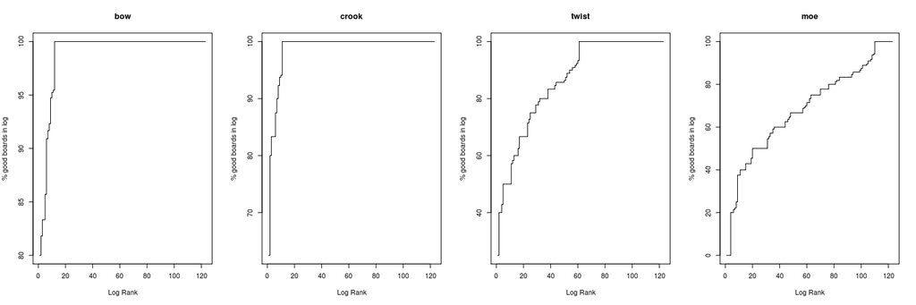

```r
keith.plot <- function (p, is.good) {
  good.frac = c()
  for (i in 1:nrow(L)) {
    ii = is.finite(B[,p]) & is.finite(B$log) & B$log==L$log[i]
    good.frac = c(good.frac, sum(ii & is.good)/sum(ii))
  }
  plot(1:nrow(L), 100*good.frac[order(good.frac)],
       type='s',
       xlab='Log Rank',
       ylab='% good boards in log',
       main=p)
}
par(mfcol=c(1,4))
keith.plot('bow',abs(B$bow)<8*60/4.9^2)
keith.plot('crook',abs(B$crook)<8*29/4.9^2)
keith.plot('twist',abs(B$twist)<asin(10/100)*180/4.9)
keith.plot('moe',B$moe>6)
```

## LS15

```r
ch = odbcConnect('LS15')
B = sqlQuery(ch, "select ScionLogNumber log, moe, den,
               abs(kappay) bow,
               abs(kappaz) crook,
               twistrate twist
             from boards_logVlumber")
L = sqlQuery(ch, "select ScionLogNumber log, volsed vol, NULL swv from logs_logVlumber")
L = summarise.boards(L,B)
```

```r
#plot_dataset(L,B)
DATASETS = c(DATASETS, list(LS15=list(L=L, B=B)))
```

# PQPV

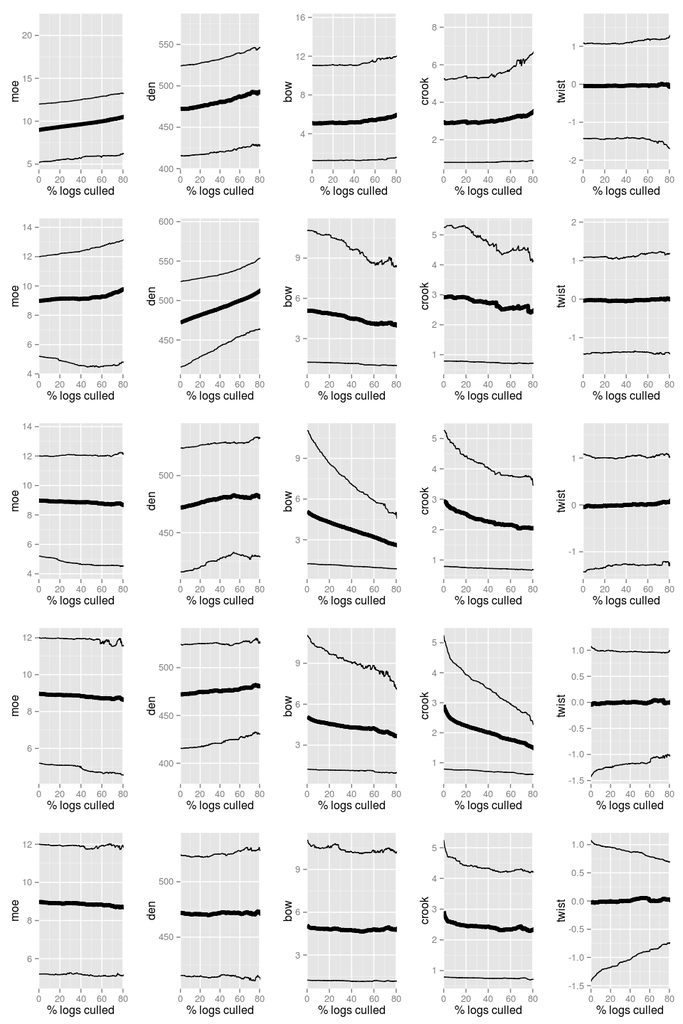

```r
ch = odbcConnect('PQPV')
B = sqlQuery(ch, "select logNumber log,
               MOEd_GPa moe,
               `density_kg1m-3` den,
               8*abs(bow)/power(j.length_m,2) bow,
               8*abs(crook)/power(j.length_m,2) crook,
               twist/j.length_m twist
             from joe90 j
             left join (select scanId, value bow from warp where measure='bow.extr_mm' and postId=1) b on j.scanId=b.scanId
             left join (select scanId, value crook from warp where measure='crook.extr_mm' and postId=1) c on j.scanId=c.scanId
             left join (select scanId, value twist from warp where measure='twist.extr_deg' and postId=1) t on j.scanId=t.scanId")
# for some reason PQPV.joe90.boardId has never been assigned!!! otherwise the above should be grouped by boardId to
# catch boards scanned more than once.
L = sqlQuery(ch, "select logNumber log, volume_m3 vol, NULL swv from logs")
L = summarise.boards(L,B)
plot_dataset(L,B)
```

```r
DATASETS = c(DATASETS, list(PQPV=list(L=L, B=B)))
```

## STR23

```r
ch = odbcConnect('STR23')
B = sqlQuery(ch, "select g.`Log id` log,
               a.`Dry acoustic stiffness (GPa)` moe,
               a.`Dry density (kg/m^3)` den,
               8*abs(midBow)*25.4/power(joescanLength*25.4/1000,2) bow,
               8*abs(midCrook)*25.4/power(joescanLength*25.4/1000,2) crook,
               asin(totalTwist/boardWidth)*180/(joescanLength*25.4/1000) twist
             from `Green boards` g
             left join `Dry board acoustic` a on g.Barcode=a.Barcode
             left join `homeWarp` h on h.boardNumber=g.Barcode
             ")
L = sqlQuery(ch, "select `Log id` log, `Volume (m^3)` vol, NULL swv  from Logs where `Volume (m^3)` is not null")
L = summarise.boards(L,B)
```

```r
#plot_dataset(L,B)
DATASETS = c(DATASETS, list(STR23=list(L=L, B=B)))
```

## Green Lumber

```r
ch = odbcConnect('GreenLumber')
B = sqlQuery(ch, "select log_id log,
               (power(swv_d,2)*(M_d/(medianArea/1e4)/(nomLength/1000)))/1000 moe,
               (M_d/(medianArea/1e4)/(nomLength/1000)) den,
               8*abs(midBow)/power(effLength/1000,2) bow,
               8*abs(midCrook)/power(effLength/1000,2) crook,
               asin(totTwist/100)*180/(effLength/1000) twist
             from boards b left join jhWarp j on b.board_id=j.boardID where j.state='Roughsawn'")
L = sqlQuery(ch, "select log_id log, NULL vol, NULL swv from logs")
L = summarise.boards(L,B)
#plot_dataset(L,B)
#DATASETS = c(DATASETS, list(GreenLumber=list(L=L, B=B))) # lets leave this out of the combined dataset till weirdness explained
```

```r
# tuck all the individual datasets away for a rainy day...
save(DATASETS, file='/home/harrinjj/G/Projects/SWI/logseg_boardquality.Rdata')
```

# Compare Distributions across Datasets

```r
#load(file='/home/harrinjj/G/Projects/SWI/logseg_boardquality.Rdata') # haul DATASETS back from disc
L.all = data.frame()
B.all = data.frame()
for (dset in names(DATASETS)) {
  browser()
  L.all = rbind(L.all, data.frame(DATASETS[[dset]][['L']], dset=dset))
  B.all = rbind(B.all, data.frame(DATASETS[[dset]][['B']], dset=dset))
  browser()
}
```

[output not shown]

```r
plots = list()
for (p in c('moe', 'den', 'bow', 'crook', 'twist')) {
    plt <- ggplot(B.all[is.finite(B[,p]),], aes_string(x=p, colour='dset')) + geom_density() + ylab('')
    plots = c(plots, list(plt))
}
#multiplot(plotlist=plots, cols=1)
```

# Combined Dataset

```r
L = L.all
B = B.all
L$log=paste(L$dset, L$log, sep=".")
B$log=paste(B$dset, B$log, sep=".")
#plot_dataset(L, B)
```

# Conclusions

Taken together these data sources included permit a meta-analysis of ~6700 boards from 587 logs. While these logs are by no means randomly chosen, they most probably provide a sufficient range to make the results at least worth thinking about.

This analysis seriously call into question ideas of improving quality (or more tenuously profitability) by rejecting a small fraction of the worst logs at mill gate.

On the other hand, in cases where logs have alternate markets, it lends support to improving product quality by selecting only the best logs.

# Next

- Add “% improved” labels to y-axis (easy - linear). Add “% removed” labels to x-axis (not so easy - nonlinear).
- Include from worst-to-all rather than cull from all-to-best. Do these results suggest buying cheaper ‘low grade’ logs is a sensible strategy (a la Sequel Lumber)?
- Use true optimal cull ordering (e.g. next remove the log that makes the biggest improvement to some distribution statistic).
- Multi-objective culls. Rather than just rejecting for one quality and looking at resulting distributions for all, cull based on all properties.
- Replot for different log grade subsets (K, S, P) GW and Carel interested in this.
- Other processing options. Instead of just culling logs, what about processing differently? (e.g. boxing out more of the pith). Can anything in this line be done without full blown simulation?
- Can you distinguish between logs containing regions where no matter how they are processed the boards will be bad vs logs where badness scattered throughout?
- Do we have the methodolgy soreted to permit running a large (on the order of a 1000 logs) randomised trial to confirm these results? Would doing such be worthwhile? Could we do a deal with a mill (new redstag???) to tie log to board and corroborate?